# ancillary data

### TQC 2026 invited talk: “A Series of Unfortunate Assumptions”

quantum

talks

Or, “Discrete log, factoring, and proofs of quantumness in 2026.” My talk as a series of blog posts.

Sep 28, 2026

2 min

### Broken assumption 1: factoring is the right thing to focus on

quantum

talks

Discrete log is probably more relevant.

Sep 28, 2026

5 min

### Broken assumption 2: input length is a lower bound on qubit count

quantum

talks

Astoundingly, we can sometimes get away with fewer than $n$ qubits.

Sep 28, 2026

9 min

### Broken assumption 3: logical qubit count is what matters

quantum

talks

With new hardware and error correction architectures, other metrics also come into play.

Sep 28, 2026

3 min

### Broken assumption 4: quantum circuits must be (mostly) reversible

quantum

talks

Measurement is a powerful tool in circuit compilation.

Sep 28, 2026

12 min

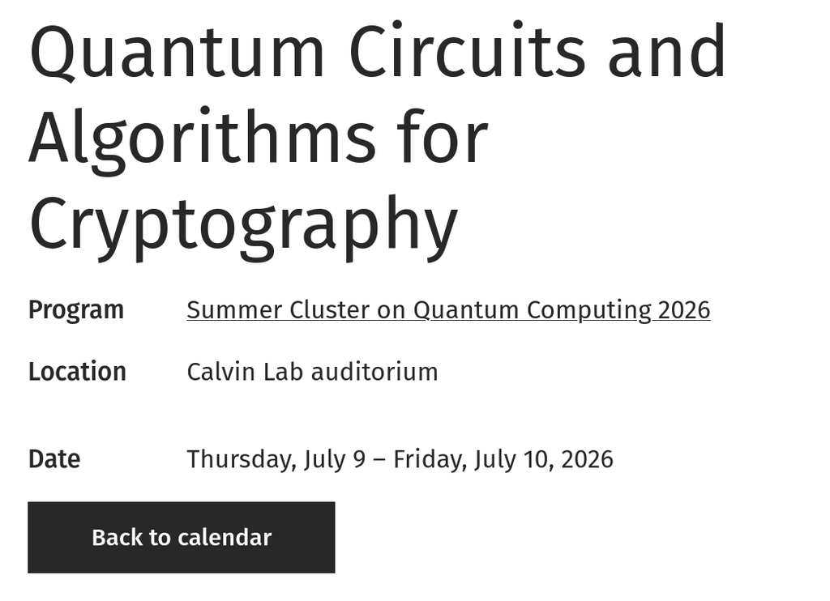

### Workshop: “Quantum Circuits and Algorithms for Cryptography”, and poll results

quantum

We voted on a name for not-post-quantum crypto, and landed on: “quantum-insecure crypto.”

Jul 14, 2026

2 min

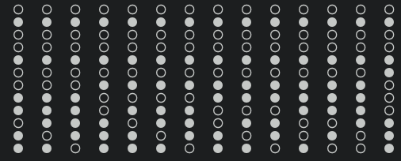

### Bit twiddling hacks for strings of constant weight

code

In which I accidentally go shoulders-deep into optimizing Julia code

Apr 11, 2025

13 min

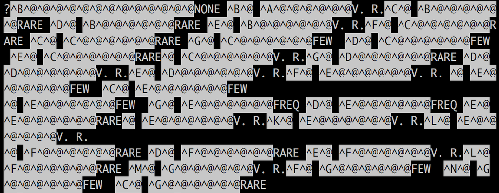

### How I saved Berkeley $20,000

fun

code

retro computing

And got repaid in snacks (and deep personal satisfaction).

Oct 24, 2024

9 min

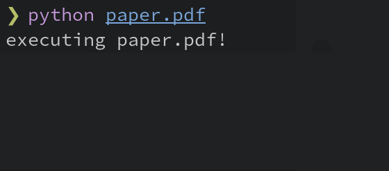

### Embedding runnable Python in PDFs

code

fun

dumb stuff with computers

Tired of distributing code with your manuscript? How about distributing your code *as* your manuscript!

Oct 12, 2024

2 min

[figure not shown]

### Numerically computing fidelities close to 1

quantum

numerics

A trick for avoiding floating-point errors when numerically computing the fidelity of quantum state vectors.

Oct 10, 2024

3 min